# DS_Capstone

### Model_4.3 XG Boots

Let’s try a third algorithm which am XGBoot

```r
  recipe(formula = Attendance ~ ., data = TRAIN) %>%
  step_nzv(all_predictors())  %>%
    step_impute_median(LaggedAttendance) %>%
  step_novel(all_nominal(), -all_outcomes()) %>%
  step_dummy(all_nominal(), -all_outcomes(), one_hot = TRUE) -> xgboost_recipe
 #XGBoot prefers one hot than dummy variables



stopping_spec <-
  boost_tree(
    trees = 500,
    mtry = tune(),
    learn_rate = tune(),
    stop_iter = tune()
  ) %>%
  set_engine("xgboost", validation = 0.2) %>%
  set_mode("regression")

stopping_grid <-
  grid_latin_hypercube(
    mtry(range = c(5L, 17L)), ## depends on number of columns in data
    learn_rate(range = c(-5, -1)), ## keep pretty big
    stop_iter(range = c(10L, 50L)), ## bigger than default
    size = 10
  )

# Where 17 is the total number of features

# Now we can put these together in a workflow and tune across the grid of parameters and our resamples.

early_stop_wf <- workflow(xgboost_recipe, stopping_spec)

set.seed(345)
stopping_rs <- tune_grid(
  early_stop_wf,
  FOLDS,
  grid = stopping_grid,
)


show_best(stopping_rs, metric = "rmse")
```

```
## # A tibble: 5 x 9
##    mtry learn_rate stop_iter .metric .estimator  mean     n std_err .config
##   <int>      <dbl>     <int> <chr>   <chr>      <dbl> <int>   <dbl> <chr>
## 1     7    0.0405         34 rmse    standard   0.732    10 0.0144  Preprocesso~
## 2     5    0.0275         29 rmse    standard   0.745    10 0.0147  Preprocesso~
## 3    10    0.00644        30 rmse    standard   0.870    10 0.0143  Preprocesso~
## 4    15    0.00275        47 rmse    standard   2.11     10 0.0109  Preprocesso~
## 5    14    0.00109        44 rmse    standard   4.44     10 0.00865 Preprocesso~
```

```r
show_best(stopping_rs, metric = "rsq")
```

```
## # A tibble: 5 x 9
##    mtry learn_rate stop_iter .metric .estimator  mean     n std_err .config
##   <int>      <dbl>     <int> <chr>   <chr>      <dbl> <int>   <dbl> <chr>
## 1     7    0.0405         34 rsq     standard   0.758    10 0.00916 Preprocesso~
## 2     5    0.0275         29 rsq     standard   0.750    10 0.00976 Preprocesso~
## 3    10    0.00644        30 rsq     standard   0.725    10 0.0108  Preprocesso~
## 4    15    0.00275        47 rsq     standard   0.705    10 0.00977 Preprocesso~
## 5    14    0.00109        44 rsq     standard   0.666    10 0.0104  Preprocesso~
```

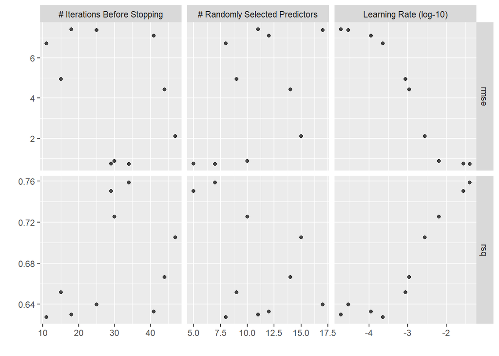

```r
autoplot(stopping_rs)
```

```r
#Select the hyperparameters  of the one who has the  minimum rmse
final_XG <- early_stop_wf %>%
  finalize_workflow(select_best(stopping_rs, metric = "rmse"))

fit_XG <- last_fit(final_XG, SPLIT)
fit_XG
```

```
## # Resampling results
## # Manual resampling
## # A tibble: 1 x 6
##   splits             id               .metrics   .notes   .predictions .workflow
##   <list>             <chr>            <list>     <list>   <list>       <list>
## 1 <split [1392/467]> train/test split <tibble [~ <tibble~ <tibble [46~ <workflo~
```

```r
collect_metrics(fit_XG)
```

```
## # A tibble: 2 x 4
##   .metric .estimator .estimate .config
##   <chr>   <chr>          <dbl> <chr>
## 1 rmse    standard       0.716 Preprocessor1_Model1
## 2 rsq     standard       0.748 Preprocessor1_Model1
```

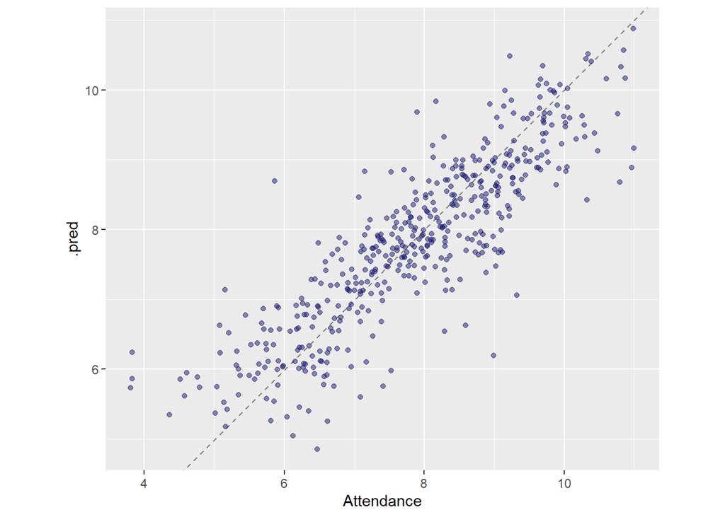

```r
collect_predictions(fit_XG) %>%
  ggplot(aes(Attendance, .pred)) +
  geom_abline(lty = 2, color = "gray50") +
  geom_point(alpha = 0.5, color = "midnightblue") +
  coord_fixed()
```

```r
# VIP
imp_spec_XG <- stopping_spec %>%
  finalize_model(select_best(stopping_rs)) %>%
  set_engine("xgboost", importance = "permutation")
workflow() %>%
  add_recipe(xgboost_recipe) %>%
  add_model(imp_spec_XG) %>%
  fit(TRAIN) %>%
  pull_workflow_fit() %>%
  vip(aesthetics = list(alpha = 0.8, fill = "midnightblue"))
```

[output not shown]

[figure not shown]

From Predicted Vs Truth plot, Bad performance with low attendance

### Model_4.4 KNN

Let’s try a forth algorithm which is KNN

```r
#Recipe
  recipe(formula = Attendance ~ ., data = TRAIN) %>%
  step_zv(all_predictors()) %>%
    step_impute_median(LaggedAttendance) %>%
  step_normalize(all_predictors(), -all_nominal()) %>%
  step_novel(all_nominal(), -all_outcomes()) %>%
  step_dummy(all_nominal(), -all_outcomes()) -> knn_recipe
#Specification
 nearest_neighbor(neighbors = tune()) %>%
  set_engine("kknn") %>%
  set_mode("regression") -> knn_spec

 # Workflow
  workflow() %>%
  add_recipe(knn_recipe) %>%
  add_model(knn_spec) -> knn_workflow

  # Create grid of hyperparameter values
knn_grid <- expand.grid(neighbors = seq(1, 100, by = 4))

knn_tune <-
  tune_race_anova(knn_workflow,
                  resamples = FOLDS,
                  grid = knn_grid,
                  )

show_best(knn_tune, metric = "rmse")
```

```
## # A tibble: 4 x 7
##   neighbors .metric .estimator  mean     n std_err .config
##       <dbl> <chr>   <chr>      <dbl> <int>   <dbl> <chr>
## 1        13 rmse    standard   0.884    10  0.0196 Preprocessor1_Model04
## 2        17 rmse    standard   0.887    10  0.0194 Preprocessor1_Model05
## 3         9 rmse    standard   0.888    10  0.0203 Preprocessor1_Model03
## 4        21 rmse    standard   0.893    10  0.0191 Preprocessor1_Model06
```

```r
show_best(knn_tune, metric = "rsq")
```

```
## # A tibble: 4 x 7
##   neighbors .metric .estimator  mean     n std_err .config
##       <dbl> <chr>   <chr>      <dbl> <int>   <dbl> <chr>
## 1        17 rsq     standard   0.645    10  0.0153 Preprocessor1_Model05
## 2        13 rsq     standard   0.644    10  0.0154 Preprocessor1_Model04
## 3        21 rsq     standard   0.643    10  0.0150 Preprocessor1_Model06
## 4         9 rsq     standard   0.640    10  0.0157 Preprocessor1_Model03
```

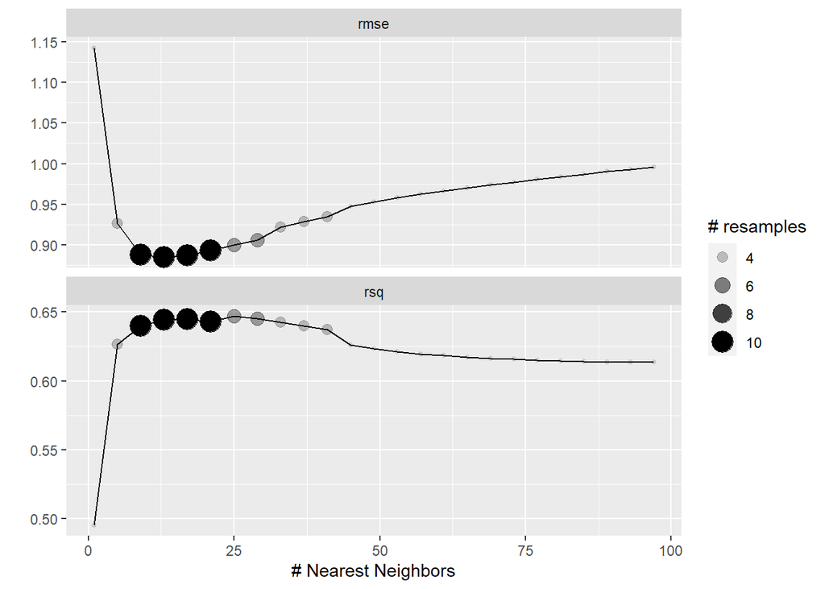

```r
autoplot(knn_tune)
```

```r
#Select the hyperparameters  of the one who has the  minimum rmse
final_knn <- knn_workflow %>%
  finalize_workflow(select_best(knn_tune, metric = "rmse"))

fit_knn <- last_fit(final_knn, SPLIT)
fit_knn
```

```
## # Resampling results
## # Manual resampling
## # A tibble: 1 x 6
##   splits             id               .metrics   .notes   .predictions .workflow
##   <list>             <chr>            <list>     <list>   <list>       <list>
## 1 <split [1392/467]> train/test split <tibble [~ <tibble~ <tibble [46~ <workflo~
```

```r
collect_metrics(fit_knn)
```

```
## # A tibble: 2 x 4
##   .metric .estimator .estimate .config
##   <chr>   <chr>          <dbl> <chr>
## 1 rmse    standard       0.849 Preprocessor1_Model1
## 2 rsq     standard       0.645 Preprocessor1_Model1
```

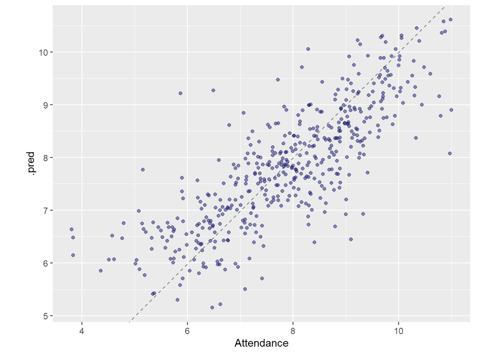

```r
collect_predictions(fit_knn) %>%
  ggplot(aes(Attendance, .pred)) +
  geom_abline(lty = 2, color = "gray50") +
  geom_point(alpha = 0.5, color = "midnightblue") +
  coord_fixed()
```

```r
# VIP
imp_spec_knn <- knn_spec %>%
  finalize_model(select_best(knn_tune, metric = "rmse")) %>%
  set_engine("kknn", importance = "permutation")
```

From Predicted Vs Truth plot, Bad performance with low attendance

So all the models have: 1- performed awful with low attendance 2- Has training RMSE higher than the one of the testing set Also, they have similar important features execpt GLMNET

# **Part5: Build models with Bootstrapping resmapling**

## Split

```r
set.seed(1234)
FOLDS_B <- bootstraps(TRAIN, strata =  Attendance)
# I've used bootstraps instead of cv folds for up-sampling purposes
```

## Models_Bootstraping

### Model_5.1: Random Forest

```r
 # Recipe is used to build the feature engineering steps. We have to specify the formula and the data which is the training
  recipe(formula = Attendance ~ ., data = TRAIN) %>%
  step_nzv(all_numeric_predictors()) %>%
  step_impute_median(LaggedAttendance) %>%
  step_normalize(all_numeric_predictors()) %>%
  step_other(Venue) %>%
 step_dummy(all_nominal_predictors()) -> ranger_recipe_B

# I'll tune:
# 1- the depth (think of it as the number the number of questions)
# 2- the minumum number of observations in the terminal nodes(leaves)
# 3- Number of trees
  rand_forest(mtry = tune(), min_n = tune(), trees = tune()) %>%
  set_mode("regression") %>%
  set_engine("ranger")-> ranger_spec_B

# The worflow is just like a storage of our model's bits
  workflow() %>%
  add_recipe(ranger_recipe_B) %>%
  add_model(ranger_spec_B) -> ranger_workflow_B

# I'll use a racing method to eliminate the combinations that did awful in the initial resamples.
# create the hyperparameter grid
hyper_grid_B <- expand.grid(
  mtry = floor(17 * c(.05, .15, .25, .333, .4, 0.5, 0.75)),
  min_n = c(1, 3, 5, 10),
  trees = c(900,1000,1100,1200)
  )
# Where 17 is the total number of features

set.seed(51510)
ranger_tune_B<-
   tune_race_anova(ranger_workflow_B,
             resamples = FOLDS_B,
             grid = hyper_grid_B)

# Let's see the result of the loss functions and the tuning results
show_best(ranger_tune_B, metric = "rmse")
```

```
## # A tibble: 1 x 9
##    mtry trees min_n .metric .estimator  mean     n std_err .config
##   <dbl> <dbl> <dbl> <chr>   <chr>      <dbl> <int>   <dbl> <chr>
## 1    12  1200     1 rmse    standard   0.767    25 0.00522 Preprocessor1_Model0~
```

```r
show_best(ranger_tune_B, metric = "rsq")
```

```
## # A tibble: 1 x 9
##    mtry trees min_n .metric .estimator  mean     n std_err .config
##   <dbl> <dbl> <dbl> <chr>   <chr>      <dbl> <int>   <dbl> <chr>
## 1    12  1200     1 rsq     standard   0.741    25 0.00353 Preprocessor1_Model0~
```

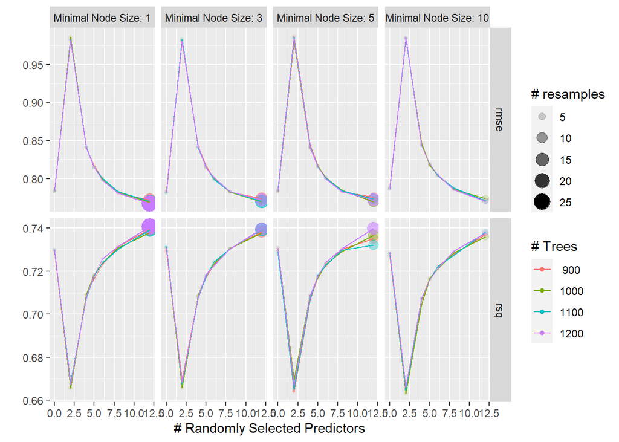

```r
autoplot(ranger_tune_B)
```

```r
# Let's take the best result and use it to update our model to finalize it
final_rf_B <- ranger_workflow_B %>%
  finalize_workflow(select_best(ranger_tune_B, metric = "rmse"))

# "last fit" will evaluate in the training then assesses it on the test set
fitRF_B <- last_fit(final_rf_B, SPLIT)
fitRF_B
```

```
## # Resampling results
## # Manual resampling
## # A tibble: 1 x 6
##   splits             id               .metrics   .notes   .predictions .workflow
##   <list>             <chr>            <list>     <list>   <list>       <list>
## 1 <split [1392/467]> train/test split <tibble [~ <tibble~ <tibble [46~ <workflo~
```

```r
collect_metrics(fitRF_B)
```

```
## # A tibble: 2 x 4
##   .metric .estimator .estimate .config
##   <chr>   <chr>          <dbl> <chr>
## 1 rmse    standard       0.706 Preprocessor1_Model1
## 2 rsq     standard       0.757 Preprocessor1_Model1
```

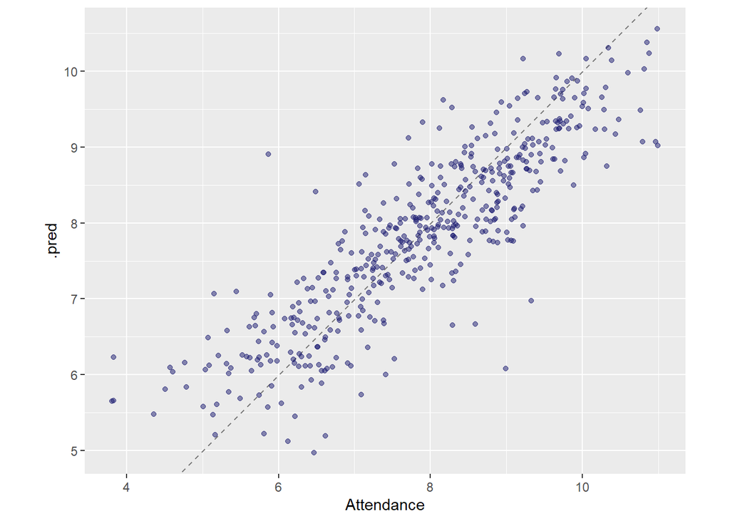

```r
# Let's plot the prediction Vs Truth values of attendance
collect_predictions(fitRF_B) %>%
  ggplot(aes(Attendance, .pred)) +
  geom_abline(lty = 2, color = "gray50") +
  geom_point(alpha = 0.5, color = "midnightblue") +
  coord_fixed()
```

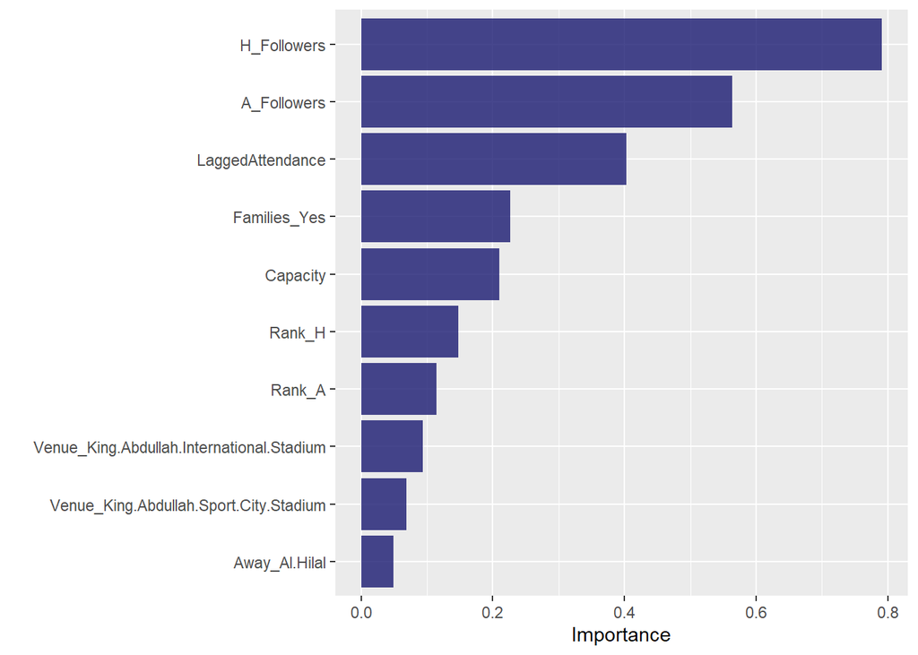

```r
# Since Random Forest is not that easy to interpret, let's use an alternative way to discover our feature by using the vip package:
imp_spec_B <- ranger_spec_B %>%
  finalize_model(select_best( ranger_tune_B)) %>%
  set_engine("ranger", importance = "permutation")
workflow() %>%
  add_recipe(ranger_recipe_B) %>%
  add_model(imp_spec_B) %>%
  fit(TRAIN) %>%
  pull_workflow_fit() %>%
  vip(aesthetics = list(alpha = 0.8, fill = "midnightblue"))
```